# NLB_retail3_analysis

```r
set.seed(1)

library(NbClust)

Index <- NbClust(segmentationData_std_NoDissimilarity, distance = "euclidean", method = "ward.D2", index = "all", min.nc = 2, max.nc = 6)
```

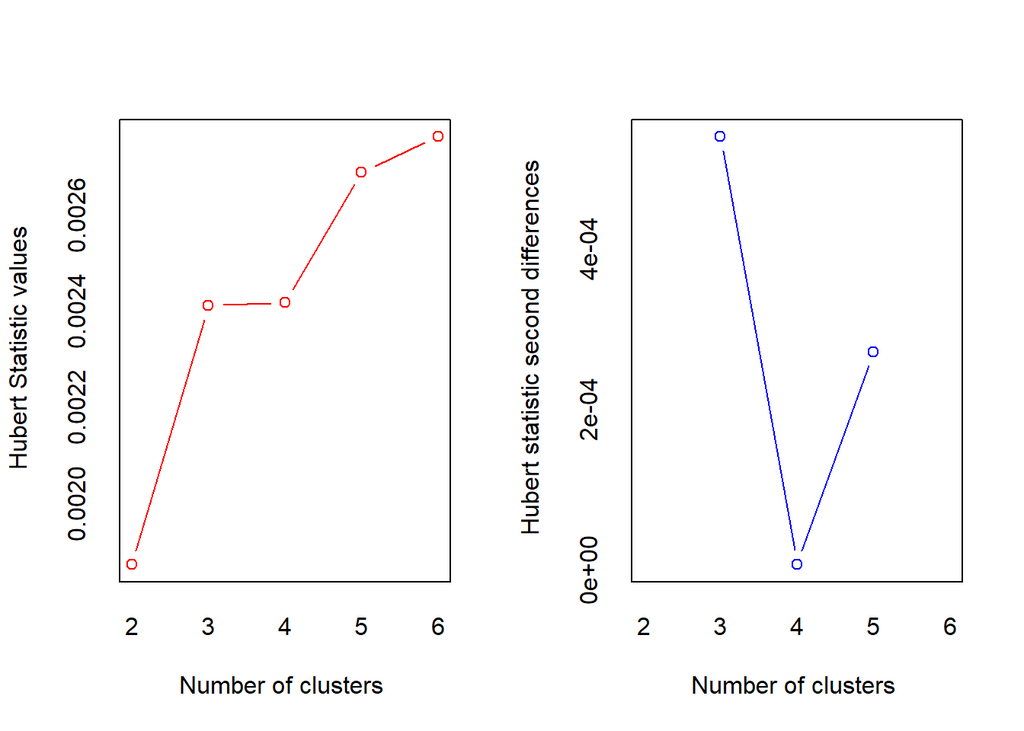

```
## *** : The Hubert index is a graphical method of determining the number of clusters.
##                 In the plot of Hubert index, we seek a significant knee that corresponds to a
##                 significant increase of the value of the measure i.e the significant peak in Hubert
##                 index second differences plot.
##
```

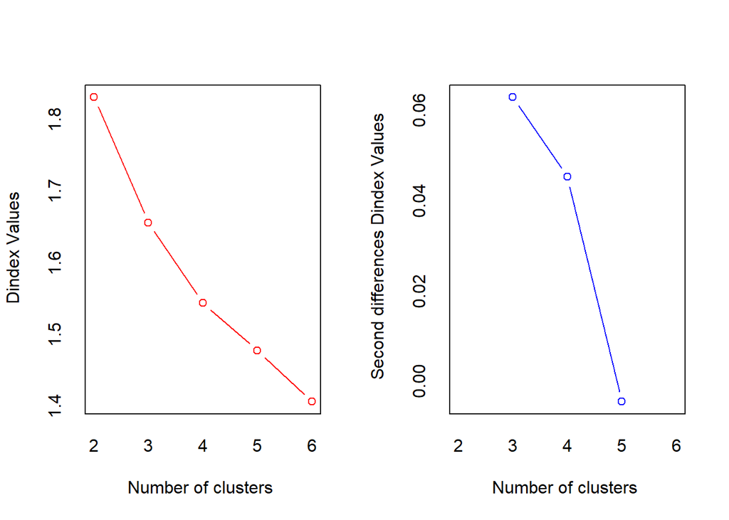

```
## *** : The D index is a graphical method of determining the number of clusters.
##                 In the plot of D index, we seek a significant knee (the significant peak in Dindex
##                 second differences plot) that corresponds to a significant increase of the value of
##                 the measure.
##
## * Among all indices:
## * 7 proposed 2 as the best number of clusters
## * 12 proposed 3 as the best number of clusters
## * 1 proposed 4 as the best number of clusters
## * 1 proposed 5 as the best number of clusters
## * 2 proposed 6 as the best number of clusters
##
##                    ***** Conclusion *****
##
## * According to the majority rule, the best number of clusters is  3
##
##
```

```r
segmentationData$Clustering_Ward <- cutree(WARD, k = 3)

head(segmentationData)
```

```
##   Age Q1a Q1b Q1c Q1d Q1e Q1f Q1g    Q1g_text Q2a Q2b Q2c Q2d Q2e Q2f Q2g Q2h
## 1   6   0   0   0   0   0   0   1 Investicije   1   0   0   0   0   0   1   0
## 2   9   1   0   0   1   0   1   0          -2   1   0   0   0   0   0   1   0
## 3   6   1   0   0   0   0   1   0          -2   1   0   0   0   1   0   0   0
## 4   9   0   0   0   0   1   0   0          -2   1   0   0   1   0   0   0   0
## 5   9   0   1   0   1   0   0   0          -2   1   0   0   1   1   0   0   0
## 6   7   1   1   1   1   1   1   0          -2   0   1   1   0   0   0   0   0
##   Q2h_text Q3a Q3b Q3c Q3d Q3e Q3f Q4a Q4b Q4c Q4d Q4e Q4f Q4g Q5a Q5b Q5c Q5d
## 1       -2   5   5   2   5   7   6   6   6 -99   4   6 -99 -99   5 -99 -99 -99
## 2       -2   5   5   7   7   7   7 -99   4   4   3 -99 -99 -99   7   7   7   7
## 3       -2   6   5   7   7   5   7 -99   6 -99 -99 -99   6 -99 -99   6 -99 -99
## 4       -2   7   5   5   7   6   7   7 -99 -99 -99 -99 -99 -99   7 -99 -99 -99
## 5       -2   6   6   7   7   7   7   7 -99 -99 -99 -99 -99 -99 -99 -99 -99 -99
## 6       -2   1   1   4   6   6   7 -99   7   5   3 -99 -99 -99 -99   4 -99   4
##   Q5e Q5f Q5g Q6a Q6b Q6c Q6d Q6e Q6f Q6g Q7a Q7b Q7c Q7d Q7e Q7f Q7g Q8
```

[output cut: 48 more lines]

```r
Leaders_initial <- aggregate(segmentationData_std_NoDissimilarity, by = list(segmentationData$Clustering_Ward), FUN = mean)

Leaders_initial
```

```
##   Group.1     LS_avg       Q21a        Q23b        Q18        Q24
## 1       1  0.1523628  0.1752398  0.05201429 -0.6492507 -0.4658517
## 2       2 -1.2375474 -1.5022115 -0.49559705  0.1288603 -0.2161551
## 3       3  0.4709733  0.5900159  0.20559703  1.1462201  1.0115893
```

```r
(kmeans_clu <- hkmeans(segmentationData_std_NoDissimilarity, k = 3, hc.metric = "euclidean", hc.method = "ward.D2"))
```

```
## Hierarchical K-means clustering with 3 clusters of sizes 90, 60, 67
##
## Cluster means:
##       LS_avg       Q21a       Q23b        Q18        Q24
## 1  0.3474340  0.3500903  0.2564023 -0.6862631 -0.6376408
## 2 -0.9991034 -1.0956980 -0.6982075 -0.1208998 -0.2705123
## 3  0.4280171  0.5109514  0.2808394  1.0301144  1.0987823
##
## Clustering vector:
##   1   2   3   4   5   6   7   8   9  10  11  12  13  14  15  16  17  18  19  20
##   1   2   3   1   1   2   1   1   3   2   3   2   2   2   3   1   2   3   3   2
##  21  22  23  24  25  26  27  28  29  30  31  32  33  34  35  36  37  38  39  40
##   1   1   2   3   2   3   3   2   1   1   1   1   3   3   2   3   3   1   2   2
##  41  42  43  44  45  46  47  48  49  50  51  52  53  54  55  56  57  58  59  60
##   3   1   3   1   2   3   3   3   3   1   1   3   2   1   1   1   3   2   3   2
```

[output cut: 26 more lines]

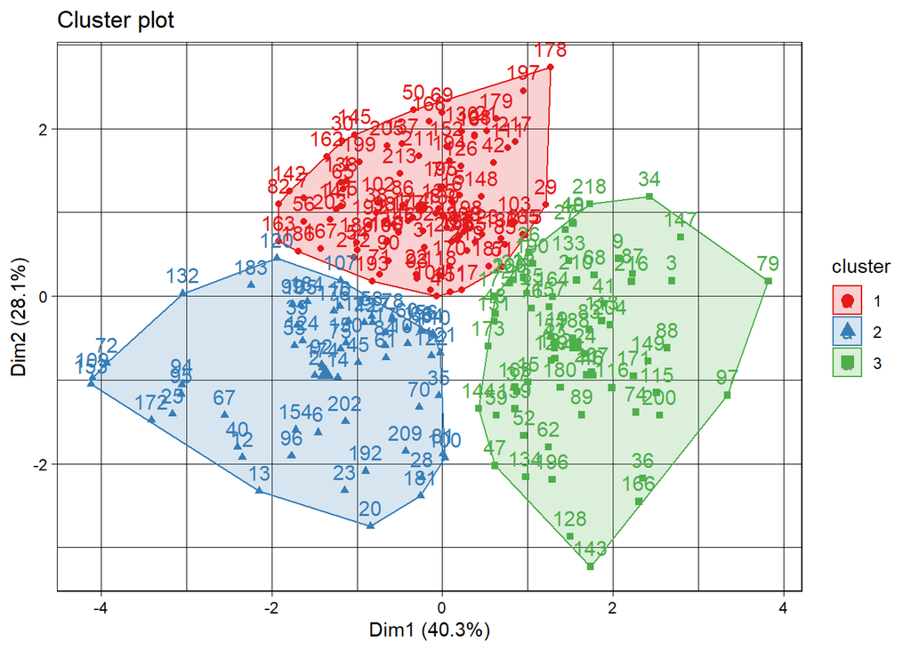

```r
fviz_cluster(kmeans_clu, palette = "Set1", repel = FALSE, ggtheme = theme_linedraw())
```

```r
R <- cor(segmentationData_std_NoDissimilarity)

round(R, 3)
```

```
##        LS_avg  Q21a   Q23b    Q18   Q24
## LS_avg  1.000 0.514  0.274  0.079 0.145
## Q21a    0.514 1.000  0.244  0.101 0.204
## Q23b    0.274 0.244  1.000 -0.009 0.232
## Q18     0.079 0.101 -0.009  1.000 0.696
## Q24     0.145 0.204  0.232  0.696 1.000
```

```r
library(psych)

cortest.bartlett(R, n = nrow(segmentationData_std_NoDissimilarity))
```

```
## $chisq
## [1] 257.257
##
## $p.value
## [1] 1.614763e-49
##
## $df
## [1] 10
```

```r
KMO(R)
```

```
## Kaiser-Meyer-Olkin factor adequacy
## Call: KMO(r = R)
## Overall MSA =  0.52
## MSA for each item =
## LS_avg   Q21a   Q23b    Q18    Q24
##   0.59   0.61   0.50   0.47   0.50
```

```r
library(FactoMineR)
```

```r
components <- PCA(segmentationData_std_NoDissimilarity, scale.unit = FALSE, graph = FALSE)

get_eigenvalue(components)
```

```
##       eigenvalue variance.percent cumulative.variance.percent
## Dim.1  2.0057648        40.301016                    40.30102
## Dim.2  1.3979001        28.087437                    68.38845
## Dim.3  0.8287534        16.651805                    85.04026
## Dim.4  0.4843047         9.730937                    94.77119
## Dim.5  0.2602355         5.228806                   100.00000
```

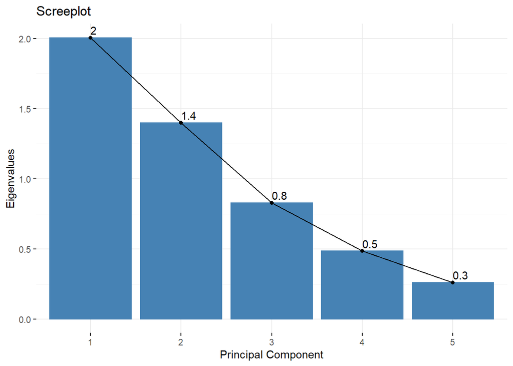

```r
fviz_eig(components, choice = "eigenvalue", main = "Screeplot", ylab = "Eigenvalues", xlab = "Principal Component", addlabels = TRUE)
```

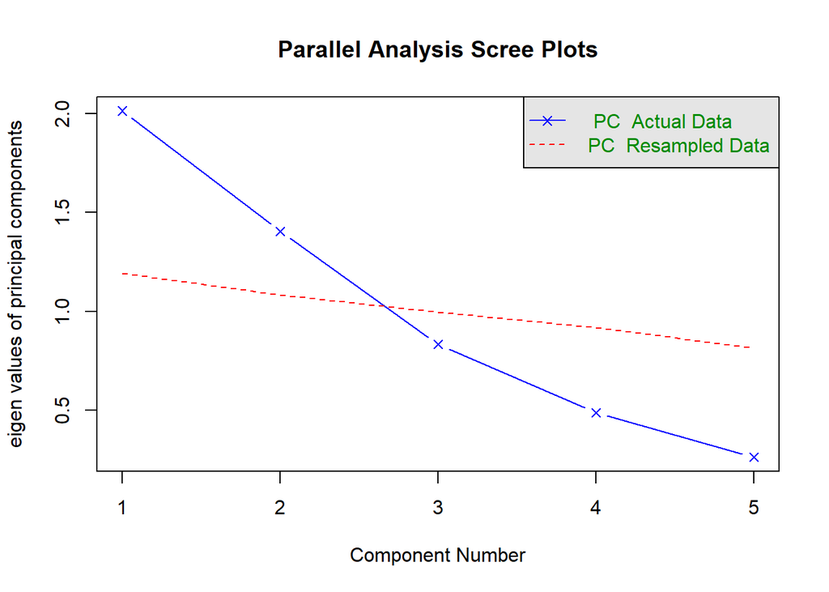

```
## Parallel analysis suggests that the number of factors =  NA  and the number of components =  2
```

```r
fa.parallel(segmentationData_std_NoDissimilarity, sim = FALSE, fa = "pc")
```

```r
(components <- PCA(segmentationData_std_NoDissimilarity, scale.unit = FALSE, graph = FALSE, ncp = 2))
```

```
## **Results for the Principal Component Analysis (PCA)**
## The analysis was performed on 217 individuals, described by 5 variables
## *The results are available in the following objects:
##
##    name               description
## 1  "$eig"             "eigenvalues"
## 2  "$var"             "results for the variables"
## 3  "$var$coord"       "coord. for the variables"
## 4  "$var$cor"         "correlations variables - dimensions"
## 5  "$var$cos2"        "cos2 for the variables"
## 6  "$var$contrib"     "contributions of the variables"
## 7  "$ind"             "results for the individuals"
## 8  "$ind$coord"       "coord. for the individuals"
## 9  "$ind$cos2"        "cos2 for the individuals"
## 10 "$ind$contrib"     "contributions of the individuals"
## 11 "$call"            "summary statistics"
## 12 "$call$centre"     "mean of the variables"
## 13 "$call$ecart.type" "standard error of the variables"
## 14 "$call$row.w"      "weights for the individuals"
## 15 "$call$col.w"      "weights for the variables"
```

```r
print(components$var$cor)
```

```
##            Dim.1      Dim.2
## LS_avg 0.6172223  0.5422439
## Q21a   0.6459849  0.4807160
## Q23b   0.4900439  0.3736032
## Q18    0.6297286 -0.6826960
## Q24    0.7616363 -0.5230700
```

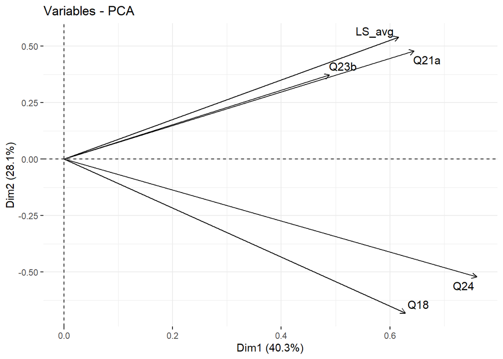

```r
fviz_pca_var(components, repel = TRUE)
```

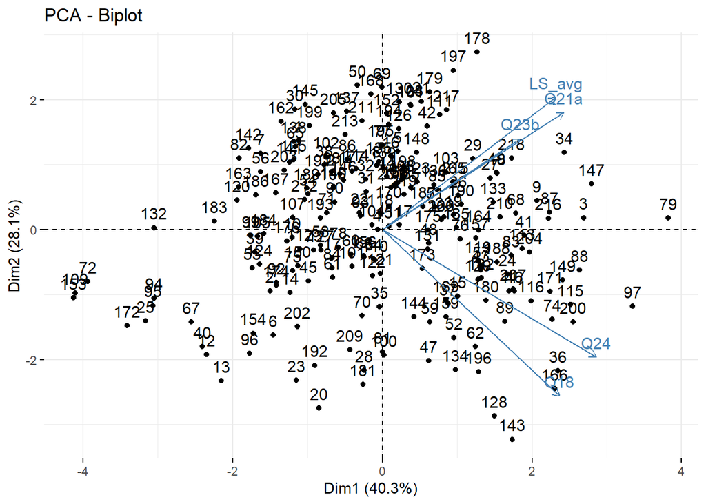

```r
fviz_pca_biplot(components)
```

```r
segmentationData$Clustering_kmeans <- kmeans_clu$cluster

# Check if we need optimization
head(segmentationData) # => uneven
```

```
##   Age Q1a Q1b Q1c Q1d Q1e Q1f Q1g    Q1g_text Q2a Q2b Q2c Q2d Q2e Q2f Q2g Q2h
## 1   6   0   0   0   0   0   0   1 Investicije   1   0   0   0   0   0   1   0
## 2   9   1   0   0   1   0   1   0          -2   1   0   0   0   0   0   1   0
## 3   6   1   0   0   0   0   1   0          -2   1   0   0   0   1   0   0   0
## 4   9   0   0   0   0   1   0   0          -2   1   0   0   1   0   0   0   0
## 5   9   0   1   0   1   0   0   0          -2   1   0   0   1   1   0   0   0
## 6   7   1   1   1   1   1   1   0          -2   0   1   1   0   0   0   0   0
##   Q2h_text Q3a Q3b Q3c Q3d Q3e Q3f Q4a Q4b Q4c Q4d Q4e Q4f Q4g Q5a Q5b Q5c Q5d
## 1       -2   5   5   2   5   7   6   6   6 -99   4   6 -99 -99   5 -99 -99 -99
## 2       -2   5   5   7   7   7   7 -99   4   4   3 -99 -99 -99   7   7   7   7
## 3       -2   6   5   7   7   5   7 -99   6 -99 -99 -99   6 -99 -99   6 -99 -99
## 4       -2   7   5   5   7   6   7   7 -99 -99 -99 -99 -99 -99   7 -99 -99 -99
## 5       -2   6   6   7   7   7   7   7 -99 -99 -99 -99 -99 -99 -99 -99 -99 -99
## 6       -2   1   1   4   6   6   7 -99   7   5   3 -99 -99 -99 -99   4 -99   4
##   Q5e Q5f Q5g Q6a Q6b Q6c Q6d Q6e Q6f Q6g Q7a Q7b Q7c Q7d Q7e Q7f Q7g Q8
```

[output cut: 48 more lines]

```r
table(segmentationData$Clustering_Ward)
```

```
##
##   1   2   3
## 117  38  62
```

```r
table(segmentationData$Clustering_kmeans)
```

```
##
##  1  2  3
## 90 60 67
```

```r
table(segmentationData$Clustering_Ward, segmentationData$Clustering_kmeans)
```

```
##
##      1  2  3
##   1 86 22  9
##   2  0 37  1
##   3  4  1 57
```

```r
Leaders_final <- kmeans_clu$centers
Leaders_final
```

```
##       LS_avg       Q21a       Q23b        Q18        Q24
## 1  0.3474340  0.3500903  0.2564023 -0.6862631 -0.6376408
## 2 -0.9991034 -1.0956980 -0.6982075 -0.1208998 -0.2705123
## 3  0.4280171  0.5109514  0.2808394  1.0301144  1.0987823
```

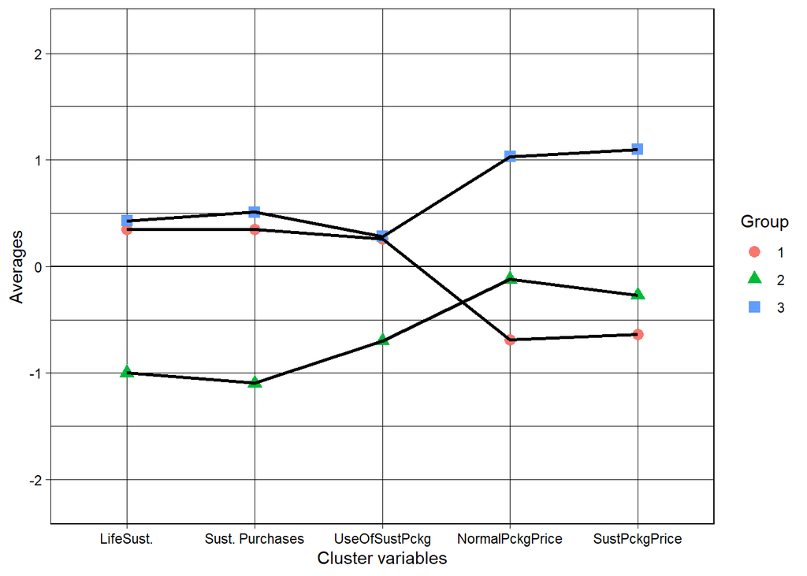

```r
# DESCRIBING CLUSTERS

Figure <- as.data.frame(Leaders_final)

Figure$ID <- 1:nrow(Figure)

library(tidyr)

Figure <- pivot_longer(Figure, cols = c("LS_avg", "Q21a", "Q23b", "Q18", "Q24"))

Figure$Group <- factor(Figure$ID, levels = c(1, 2, 3), labels = c("1", "2", "3"))

Figure$NameF <- factor(Figure$name,
                       levels = c("LS_avg", "Q21a", "Q23b", "Q18", "Q24"),
                       labels = c("LifeSust.", "Sust. Purchases", "UseOfSustPckg", "NormalPckgPrice", "SustPckgPrice"))

library(ggplot2)

ggplot(Figure, aes(x = NameF, y = value)) +
  geom_hline(yintercept = 0) +
  theme_linedraw() +
  geom_point(aes(shape = Group, col = Group), size = 3) +
  geom_line(aes(group = ID), size = 1) +
  ylab("Averages") +
  xlab("Cluster variables") +
  ylim(-2.2, 2.2)
```

```r
# aware and willing, not aware but willing, not aware
```

```r
fit <- aov(cbind(LS_avg, Q21a, Q23b, Q18, Q24) ~ as.factor(Clustering_kmeans), data = segmentationData )
# TODO: Ask: WHICH DATA DO WE USE HERE? STD OR INITIAL????

summary(fit) # all p values are good
```

```
##  Response LS_avg :
##                               Df  Sum Sq Mean Sq F value    Pr(>F)
## as.factor(Clustering_kmeans)   2  88.477  44.239  66.814 < 2.2e-16 ***
## Residuals                    214 141.692   0.662
## ---
## Signif. codes:  0 '***' 0.001 '**' 0.01 '*' 0.05 '.' 0.1 ' ' 1
##
##  Response Q21a :
##                               Df Sum Sq Mean Sq F value    Pr(>F)
## as.factor(Clustering_kmeans)   2 207.68 103.840  93.201 < 2.2e-16 ***
## Residuals                    214 238.43   1.114
## ---
## Signif. codes:  0 '***' 0.001 '**' 0.01 '*' 0.05 '.' 0.1 ' ' 1
##
##  Response Q23b :
##                               Df Sum Sq Mean Sq F value    Pr(>F)
## as.factor(Clustering_kmeans)   2 155.59  77.796  24.655 2.313e-10 ***
## Residuals                    214 675.25   3.155
## ---
## Signif. codes:  0 '***' 0.001 '**' 0.01 '*' 0.05 '.' 0.1 ' ' 1
##
##  Response Q18 :
##                               Df Sum Sq Mean Sq F value    Pr(>F)
## as.factor(Clustering_kmeans)   2 1561.2  780.58  120.39 < 2.2e-16 ***
## Residuals                    214 1387.5    6.48
## ---
## Signif. codes:  0 '***' 0.001 '**' 0.01 '*' 0.05 '.' 0.1 ' ' 1
##
##  Response Q24 :
##                               Df Sum Sq Mean Sq F value    Pr(>F)
## as.factor(Clustering_kmeans)   2 2330.9 1165.45  138.54 < 2.2e-16 ***
## Residuals                    214 1800.2    8.41
## ---
## Signif. codes:  0 '***' 0.001 '**' 0.01 '*' 0.05 '.' 0.1 ' ' 1
```

### VALIDATION

```r
# Further ( + descriptive) analysis needs to be perfomed

# PRIMARY FACTORS:
# GenderF
segmentationData$GenderF <- factor(segmentationData$XSPOL,
                            levels = c(1, 2),
                            labels = c("M", "F"))

# AgeF
segmentationData$AgeF <- factor(segmentationData$Age,
                            levels = c(2, 3, 4, 5, 6, 7, 8, 9, 10, 11),
                            labels = c("18", "19", "20", "21", "22", "23", "24", "25", "26", "27"))

# NeobankUseF
segmentationData$NeobankUseF <- factor(segmentationData$Q16,
                            levels = c(1, 2),
                            labels = c("Yes", "No"))

# FrequencyOfDigitalPurchasesF
segmentationData$FrequencyOfDigitalPurchasesF <- factor(segmentationData$Q11a,
                            levels = c(1, 2, 3, 4, 5),
                            labels = c("Not at all", " Once per month", "Several times per month", "Several times per week", "Every day"))

# ADDITIONAL:
#DigitalBankF
segmentationData$DigitalBankF <- factor(segmentationData$Q16,
                            levels = c(1, 2),
                            labels = c("Yes", "No"))
# BankTypePreferenceF
segmentationData$BankTypePreferenceF <- factor(segmentationData$Q17,
                            levels = c(1, 2),
                            labels = c("Digital", "Traditional"))

# ImpactOnEnvironmentF
segmentationData$ImpactOnEnvironmentF <- factor(segmentationData$Q22,
                            levels = c(1, 2),
                            labels = c("Yes", "No"))
# EmploymentF
segmentationData$EmploymentF <- factor(segmentationData$XDS2a4,
                            levels = c(1, 2),
                            labels = c("Student", "Employed"))

# LivingParentsF
segmentationData$LivingParentsF <- factor(segmentationData$Q31,
                            levels = c(1, 2),
                            labels = c("Yes", "No"))

# KidsF
segmentationData$KidsF <- factor(segmentationData$XSPOL1,
                            levels = c(1, 2),
                            labels = c("Yes", "No"))

# SalaryF
segmentationData$SalaryF <- factor(segmentationData$Q30,
                            levels = c(1, 2, 3, 4, 5, 6, 7),
                            labels = c("Brez dohodka", "0-499", "500-999", "1000-1499", "1500-1999", "2000-2499", "2500+"))

# EducationF
segmentationData$EducationF <- factor(segmentationData$XIZ1a2,
                            levels = c(1, 2, 3, 4, 5, 6, 7),
                            labels = c("Srednja sola", "Visja sola", "Visoka sola", "Uni. sola", "Magister", "Doktorat", "Other"))




segmentationData$AgeF <- as.numeric(as.character(segmentationData$AgeF))

aggregate(segmentationData$AgeF,
          by = list(segmentationData$Clustering_kmeans),
          FUN = 'mean')
```

```
##   Group.1        x
## 1       1 22.30000
## 2       2 22.98333
## 3       3 22.22388
```

```r
Fit <- aov(AgeF ~ as.factor(Clustering_kmeans), data= segmentationData)

summary(Fit)
```

```
##                               Df Sum Sq Mean Sq F value Pr(>F)
## as.factor(Clustering_kmeans)   2   22.5  11.233   1.825  0.164
## Residuals                    214 1317.5   6.157
```

#### H0: meanG1 = meanG2 = meanG3

#### H1: At least one mean is different.

#### We cannot reject H0 because p-value is too high. The means of the three groups are too similar to be statistically significant.

#### Calculating the effect size: r**2=22.5/(22.5 + 1317.5) = 0.017

#### Effect size is small, the differences are small.

```r
segmentationData$Q11a <- as.numeric(as.character(segmentationData$Q11a))

aggregate(segmentationData$Q11a,
          by = list(segmentationData$Clustering_kmeans),
          FUN = 'mean')
```

```
##   Group.1        x
## 1       1 2.977778
## 2       2 3.116667
## 3       3 3.343284
```

```r
Fit1 <- aov(Q11a ~ as.factor(Clustering_kmeans), data= segmentationData)

summary(Fit1)
```

```
##                               Df Sum Sq Mean Sq F value Pr(>F)
## as.factor(Clustering_kmeans)   2    5.1   2.572   1.407  0.247
## Residuals                    214  391.2   1.828
```

#### H0: meanG1 = meanG2 = meanG3

#### H1: At least one mean is different.

#### We cannot reject H0 because p-value is too high. The means of the three groups are too similar to be statistically significant.

```r
chisq_resultsGen <- chisq.test(segmentationData$GenderF, as.factor(segmentationData$Clustering_kmeans))
chisq_resultsGen
```

```
##
##  Pearson's Chi-squared test
##
## data:  segmentationData$GenderF and as.factor(segmentationData$Clustering_kmeans)
## X-squared = 1.0725, df = 2, p-value = 0.5849
```

```r
addmargins(chisq_resultsGen$observed)
```

```
##
## segmentationData$GenderF   1   2   3 Sum
##                      M    33  27  26  86
##                      F    57  33  41 131
##                      Sum  90  60  67 217
```

```r
round(chisq_resultsGen$expected, 2)
```

```
##
## segmentationData$GenderF     1     2     3
##                        M 35.67 23.78 26.55
##                        F 54.33 36.22 40.45
```

#### This is acceptable because all values are above 5.

```r
round(chisq_resultsGen$res, 2)
```

```
##
## segmentationData$GenderF     1     2     3
##                        M -0.45  0.66 -0.11
##                        F  0.36 -0.54  0.09
```

#### No validation because none of these are higher than 1.64 in absolute terms - values are too low to be statistically significant.

```r
chisq_resultsImp <- chisq.test(segmentationData$ImpactOnEnvironmentF, as.factor(segmentationData$Clustering_kmeans))
chisq_resultsImp
```

```
##
##  Pearson's Chi-squared test
##
## data:  segmentationData$ImpactOnEnvironmentF and as.factor(segmentationData$Clustering_kmeans)
## X-squared = 30.857, df = 2, p-value = 1.993e-07
```

```r
addmargins(chisq_resultsImp$observed)
```

```
##
##         1   2   3 Sum
##   Yes  73  24  51 148
##   No   17  36  16  69
##   Sum  90  60  67 217
```

```r
round(chisq_resultsImp$expected, 2)
```

```
##
##           1     2    3
##   Yes 61.38 40.92 45.7
##   No  28.62 19.08 21.3
```

```r
round(chisq_resultsImp$res, 2)
```

```
##
##           1     2     3
##   Yes  1.48 -2.65  0.78
##   No  -2.17  3.87 -1.15
```

#### This is acceptable because all of these values are above 5 (expected values).

#### In Group1, there is less people than expected that answered NO. In Group2, there is more people than expected that answered NO. In Group3, there is no significant difference.

#### With the variable ImpactonEnvironmentF, we validated the results because the results were not what we expected.In Group 2, there are less people than expected who want to know about their impact on the environment and more people than expected who do not want to know about their impact.

```r
# Lets do Cramer test to see the effect size and interpret

library(DescTools)
CramerV(segmentationData$ImpactOnEnvironmentF, as.factor(segmentationData$Clustering_kmeans))
```

```
## [1] 0.377094
```

```r
# can see that this is mid effect <= check theory and fix this verdict, 0.377

# Denis then did fisher test here

fisher.test(segmentationData$ImpactOnEnvironmentF, as.factor(segmentationData$Clustering_kmeans))
```

```
##
##  Fisher's Exact Test for Count Data
##
## data:  segmentationData$ImpactOnEnvironmentF and as.factor(segmentationData$Clustering_kmeans)
## p-value = 3.986e-07
## alternative hypothesis: two.sided
```

```r
chisq_resultsDig<- chisq.test(segmentationData$DigitalBankF, as.factor(segmentationData$Clustering_kmeans))
chisq_resultsDig
```

```
##
##  Pearson's Chi-squared test
##
## data:  segmentationData$DigitalBankF and as.factor(segmentationData$Clustering_kmeans)
## X-squared = 3.7445, df = 2, p-value = 0.1538
```

```r
addmargins(chisq_resultsDig$observed)
```

```
##
## segmentationData$DigitalBankF   1   2   3 Sum
##                           Yes  58  43  37 138
##                           No   32  17  30  79
##                           Sum  90  60  67 217
```

```r
round(chisq_resultsDig$expected, 2)
```

```
##
## segmentationData$DigitalBankF     1     2     3
##                           Yes 57.24 38.16 42.61
##                           No  32.76 21.84 24.39
```

```r
round(chisq_resultsDig$res, 2)
```

```
##
## segmentationData$DigitalBankF     1     2     3
##                           Yes  0.10  0.78 -0.86
##                           No  -0.13 -1.04  1.14
```

#### Values are too low to be statistically significant.

```r
chisq_resultsEmp <- chisq.test(segmentationData$EmploymentF, as.factor(segmentationData$Clustering_kmeans))
chisq_resultsEmp
```

```
##
##  Pearson's Chi-squared test
##
## data:  segmentationData$EmploymentF and as.factor(segmentationData$Clustering_kmeans)
## X-squared = 8.8122, df = 2, p-value = 0.0122
```

```r
addmargins(chisq_resultsEmp$observed)
```

```
##
## segmentationData$EmploymentF   1   2   3 Sum
##                     Student   71  35  52 158
##                     Employed  19  25  15  59
##                     Sum       90  60  67 217
```

```r
round(chisq_resultsEmp$expected, 2)
```

```
##
## segmentationData$EmploymentF     1     2     3
##                     Student  65.53 43.69 48.78
##                     Employed 24.47 16.31 18.22
```

```r
round(chisq_resultsEmp$res, 2)
```

```
##
## segmentationData$EmploymentF     1     2     3
##                     Student   0.68 -1.31  0.46
##                     Employed -1.11  2.15 -0.75
```

#### In Group 2, more people than expected are employed.In Group 1 and Group 3, the differences are too small to be statistically significant.

```r
chisq_resultsLiv <- chisq.test(segmentationData$LivingParentsF, as.factor(segmentationData$Clustering_kmeans))
chisq_resultsLiv
```

```
##
##  Pearson's Chi-squared test
##
## data:  segmentationData$LivingParentsF and as.factor(segmentationData$Clustering_kmeans)
## X-squared = 0.56225, df = 2, p-value = 0.7549
```

```r
addmargins(chisq_resultsLiv$observed)
```

```
##
##         1   2   3 Sum
##   Yes  64  42  44 150
##   No   26  18  23  67
##   Sum  90  60  67 217
```

```r
round(chisq_resultsLiv$expected, 2)
```

```
##
##           1     2     3
##   Yes 62.21 41.47 46.31
##   No  27.79 18.53 20.69
```

```r
round(chisq_resultsLiv$res, 2)
```

```
##
##           1     2     3
##   Yes  0.23  0.08 -0.34
##   No  -0.34 -0.12  0.51
```

#### Values are too low to be statistically significant.

## We performed hierarchical clustering of 217 units based on 5 cluster variables (Squared Euclidean Distance, Ward Algorithm). The results were further optimized with k-means clustering.

#### Description of Cluster 1:

#### Name: GREEN PENNY-PINCHERS

#### Cluster 1 represents the largest group of customers (estimated at 41 %) who believe that sustainability is important. They lead a sustainable lifestyle on a daily basis, consider sustainability when making purchases and would be interested in using a sustainable financial solution integrated into their digital bank. In this group, there are fewer people than expected that said that they would not like to know their impact on the environment based on their spending habits, which further confirms their awareness about sustainability. These customers are not prepared to pay either for a normal banking package or for a sustainable banking package.In this group, there are 37 % of men and 63 % of women, 64 % use a digital bank and 36 % do not. The first group consists of 79 % students and 21 % of employed young individuals which could explain the fact that customers in this group are not prepared to pay for banking packages since students mostly have less money to spend than employed individuals.

#### Description of Cluster 2:

#### Name: ANTI-GREENIES

#### Cluster 2 represents the smallest group of customers (estimated at 28 %) who are not aware of the importance of sustainability. They do not lead a sustainable lifestyle on a daily basis, do not consider sustainability when making purchases and would not be interested in using a sustainable financial solution integrated into their digital bank. More than expected, this group would not be interested in knowing about the impact their spending has on the environment, which further confirms them being unaware of the importance of sustainability. These customers are not prepared to pay for both a normal banking package as well as a sustainable banking package. In this group, there are 45 % of men and 55 % of women, 72 % use a digital bank and 28 % do not. The second group consists of 58 % of students and 42 % of employed young people. Considering the variable of employment, there are more employed young individuals in this group than expected, which can be explained by them being unaware of the importance of sustainability which they consider as a cause on which they are not prepared to spend their money.

#### Description of Cluster 3:

#### Name: GENEROUS ENVIRONMENTALISTS

#### Cluster 3 represents the second largest group of customers (estimated at 31 %) who believe that sustainability is important. They lead a sustainable lifestyle on a daily basis, consider sustainability when making purchases and would be interested in using a sustainable financial solution integrated into their digital bank. These customers are prepared to pay for both their normal banking package as well as a sustainable banking package.In this group, there are 39 % of men and 61 % of women, 55 % use a digital bank and 45 % do not. The third group consists of 78 % students and 22 % of employed young individuals, which is interesting because the group constitution based on employment is very similar to the first group, so these customers clearly consider sustainability as a cause that is worth spending money on since they are prepared to pay for a sustainable banking package.